# Grafika rastrowa - Laboratorium 1

## Zadania wykonane w ramach sprawozdania

### 1. Importowanie bibliotek

```python
import numpy as np
import matplotlib.pyplot as plt
```

### 2. Wczytywanie obrazka z tęczą

```python
img = plt.imread('rainbow.png')
```

### 3. Wypisanie typu i rozmiaru obrazka

```python
print(img.shape, img.dtype)
```

```
(1728, 3242, 4) float32
```

### Zadanie 1: Co oznaczają liczby zawarte w shape?

Liczby w `img.shape` oznaczają wymiary obrazka:

- Pierwsza liczba: wysokość obrazka (liczba wierszy pikseli)
- Druga liczba: szerokość obrazka (liczba kolumn pikseli)
- Trzecia liczba: liczba kanałów kolorów (zazwyczaj 3 dla RGB lub 4 dla RGBA)

Przykładowo, jeśli `shape = (480, 640, 3)`, to obrazek ma 480 pikseli wysokości, 640 pikseli szerokości i 3 kanały (czerwony, zielony, niebieski).

### Zadanie 2: Jaki mamy typ zmiennych? Jaki zakres wartości posiada w przypadku obrazku?

Typ zmiennych zależy od formatu obrazka:

- Dla formatu PNG: zazwyczaj `float32` lub `float64` z zakresem wartości **0.0 do 1.0**
- Dla formatu JPG: zazwyczaj `uint8` z zakresem wartości **0 do 255**

W przypadku typu `float` wartość 0.0 oznacza kolor czarny, a 1.0 oznacza maksymalną intensywność koloru (biały dla kanałów RGB). W przypadku typu `uint8` wartość 0 oznacza kolor czarny, a 255 oznacza maksymalną intensywność.

### 4. Wyświetlenie obrazka

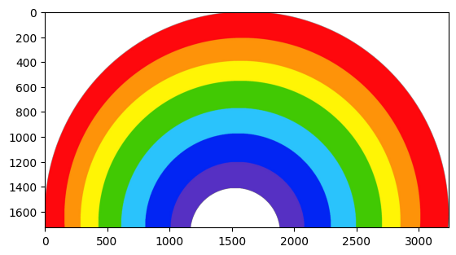

```python
plt.imshow(img)
plt.show()
```

### 5. Wyświetlenie tylko wartości koloru czerwonego

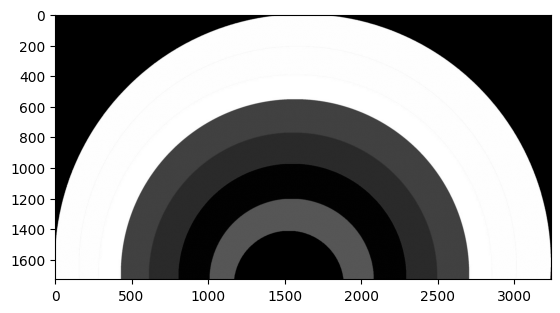

```python
plt.imshow(img[:,:,0], cmap='gray')
plt.show()
```

### Zadanie 3: Wyświetlenie składowych RGB w subplot

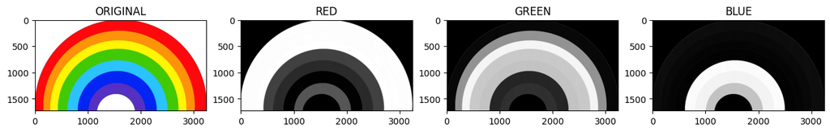

```python
plt.figure(figsize=(16, 4))

plt.subplot(1, 4, 1)
plt.title('ORIGINAL')
plt.imshow(img)

plt.subplot(1, 4, 2)
plt.title('RED')
plt.imshow(img[:,:,0], cmap='gray')

plt.subplot(1, 4, 3)
plt.title('GREEN')
plt.imshow(img[:,:,1], cmap='gray')

plt.subplot(1, 4, 4)
plt.title('BLUE')
plt.imshow(img[:,:,2], cmap='gray')

plt.show()
```

### Zadanie 4: Implementacja funkcji konwersji RGB do odcieni szarości

```python
def rgb_to_gray(image):
    """
    Konwertuje obrazek RGB na odcienie szarości używając wzoru:
    Y = 0.299*R + 0.587*G + 0.114*B

    Parametry:
    image - obrazek RGB (tablica numpy 3D)

    Zwraca:
    Obrazek w odcieniach szarości (tablica numpy 2D)
    """
    R = image[:,:,0]
    G = image[:,:,1]
    B = image[:,:,2]

    Y = 0.299 * R + 0.587 * G + 0.114 * B

    return Y
```

### 7. Wczytanie innego obrazka (zdjęcie)

```python
photo = plt.imread('photo.jpg')
```

### 8. Zamiana obrazka na odcienie szarości

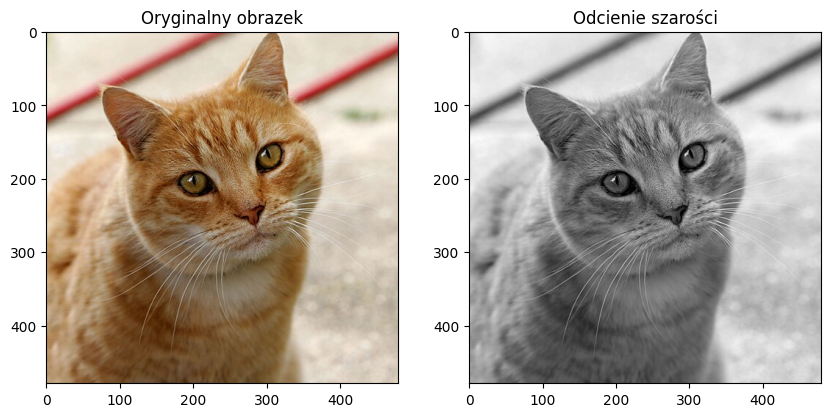

```python
if photo.dtype == np.uint8:
    photo_float = photo.astype(np.float32) / 255.0
else:
    photo_float = photo.copy()

gray_photo = rgb_to_gray(photo_float)

plt.figure(figsize=(10, 5))

plt.subplot(1, 2, 1)
plt.title('Oryginalny obrazek')
plt.imshow(photo)

plt.subplot(1, 2, 2)
plt.title('Odcienie szarości')
plt.imshow(gray_photo, cmap='gray')

plt.show()
```